# Final Project Analysis

## Linearity Assessment

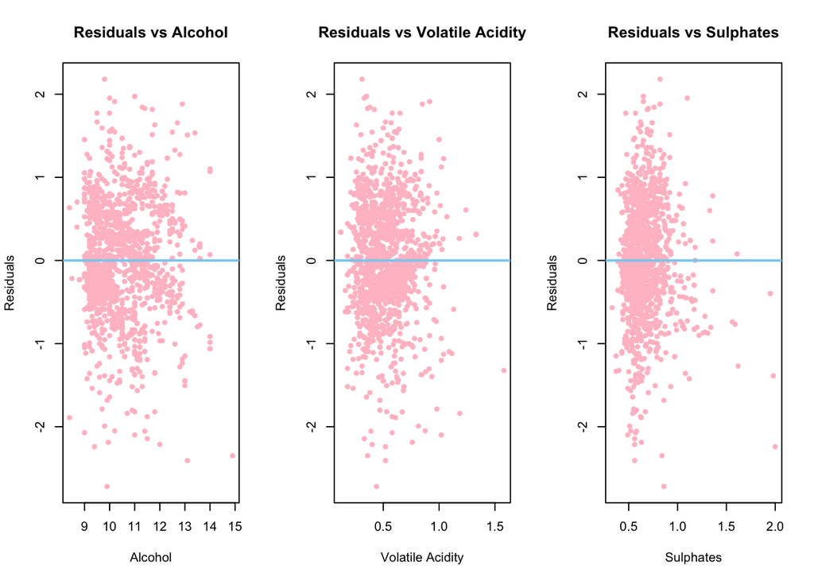

```r
# Residuals vs individual predictors
par(mfrow = c(1, 3))
plot(wine_data$alcohol, residuals(initial_model),
     main = "Residuals vs Alcohol",
     xlab = "Alcohol", ylab = "Residuals",
     pch = 19, col = "pink", cex = 0.7)
abline(h = 0, col = "#89CFF0", lwd = 2)

plot(wine_data$volatile.acidity, residuals(initial_model),
     main = "Residuals vs Volatile Acidity",
     xlab = "Volatile Acidity", ylab = "Residuals",
     pch = 19, col = "pink", cex = 0.7)
abline(h = 0, col = "#89CFF0", lwd = 2)

plot(wine_data$sulphates, residuals(initial_model),
     main = "Residuals vs Sulphates",
     xlab = "Sulphates", ylab = "Residuals",
     pch = 19, col = "pink", cex = 0.7)
abline(h = 0, col = "#89CFF0", lwd = 2)
```

```r
par(mfrow = c(1, 1))
```

The residual plots do not show obvious patterns, suggesting that the linearity assumption is reasonably satisfied. There is some slight curvature in the relationship with volatile acidity, which might benefit from transformation.

## Normality of Residuals

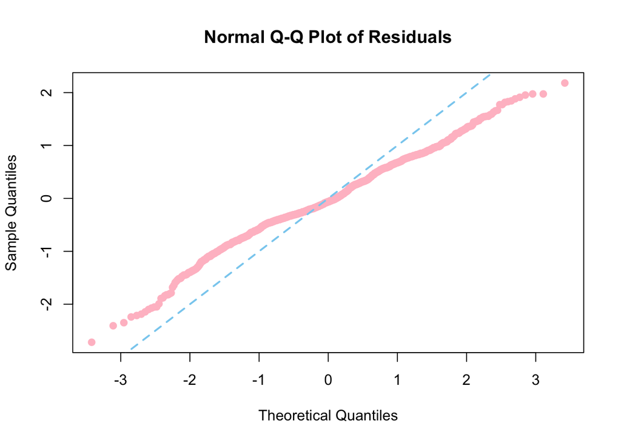

```r
# QQ plot of residuals
qqnorm(initial_model$residuals, main = "Normal Q-Q Plot of Residuals",
       pch = 19, col = "pink")
abline(0, 1, col = "#89CFF0", lwd = 2, lty = 2)
```

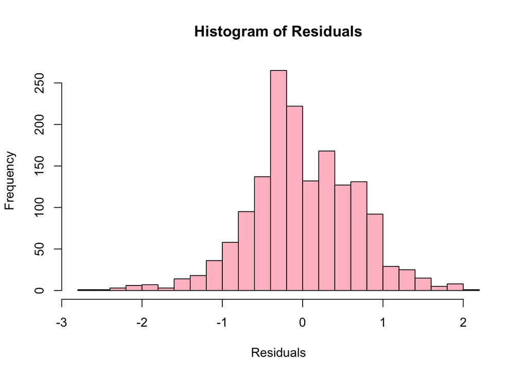

```r
# Histogram of residuals
hist(initial_model$residuals, breaks = 30, col = "pink",
     main = "Histogram of Residuals", xlab = "Residuals")
```

The QQ plot shows some deviation from normality in the tails. The histogram of residuals is roughly symmetric but has some slight deviations from a normal distribution.

##Homoscedasticity

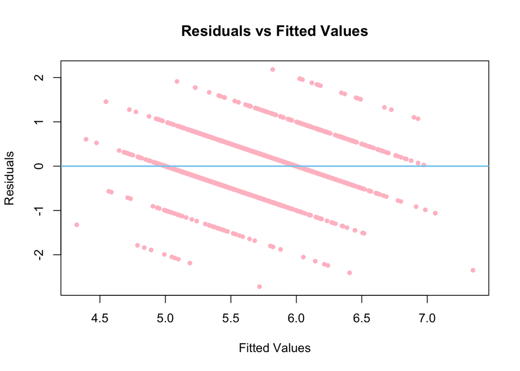

```r
# Plot residuals vs fitted values
plot(initial_model$fitted.values, initial_model$residuals,
     xlab = "Fitted Values", ylab = "Residuals",
     main = "Residuals vs Fitted Values",
     pch = 19, col = "pink", cex = 0.7)
abline(h = 0, col = "#89CFF0", lwd = 2)
```

```r
# Breusch-Pagan test for homoscedasticity
bp_test <- bptest(initial_model)
print(bp_test)
```

```
##
##  studentized Breusch-Pagan test
##
## data:  initial_model
## BP = 40.937, df = 3, p-value = 6.744e-09
```

The Breusch-Pagan test is significant (p-value < 0.001), indicating that the homoscedasticity assumption is violated. The residual plot shows some pattern with the variance changing with fitted values.